# Reduced sparse monkey PK study design analysis

NAMLink

## Purpose

This report documents the reduced sparse monkey PK study-design analysis for AUC0-28d, Cmax, and terminal clearance. The analysis compares study arithmetic means with full rich-population arithmetic means using the standard fold error:

`fold error = reduced-study estimate / rich-population reference`.

The prespecified acceptable interval is 0.5-2.0. Candidate group sizes are 2, 3, and 4 animals per dose group; five-animal groups are excluded from every scenario.

The analysis is predefined for atezolizumab, avelumab, nivolumab, and pembrolizumab. Run 4 top-down estimates and relative standard errors (RSEs) are read directly from the final monkey-model fit. Parameter uncertainty is represented by available RSEs, and 30% interindividual variability (IIV) is specified independently for CL, V1, Q, and V2. A structural parameter fixed in Run 4, and therefore missing an estimated RSE, is assigned a 40% RSE.

```r
rm(list = ls())

suppressPackageStartupMessages({
  library(dplyr)
  library(knitr)
  library(purrr)
  library(tibble)
})

MOLECULES <- c(
  "Atezolizumab",
  "Avelumab",
  "Nivolumab",
  "Pembrolizumab"
)
IIV_CV_PERCENT <- 30
N_PER_GROUP <- 2:4
ENDPOINTS <- c("AUC0-28d", "Cmax", "Terminal clearance")

study_dir <- if (
  basename(normalizePath(".", winslash = "/", mustWork = TRUE)) ==
    "06_StudySimulations"
) {
  normalizePath(".", winslash = "/", mustWork = TRUE)
} else {
  normalizePath("06_StudySimulations", winslash = "/", mustWork = TRUE)
}
project_dir <- normalizePath(
  file.path(study_dir, ".."),
  winslash = "/",
  mustWork = TRUE
)
run4_file <- file.path(
  project_dir,
  "04_TopDown",
  "SimsOutputs",
  "TopDownTMDD_Run4_CL_Vc_Q_Vp_fixed_TMDD_Monkey.rds"
)
fold_error_figure_file <- file.path(
  study_dir,
  "SimsOutputs",
  "Figures",
  "Gate2_design_standard_fold_error_by_endpoint.png"
)
power_figure_file <- file.path(
  study_dir,
  "SimsOutputs",
  "Figures",
  "Gate2_design_power_by_endpoint.png"
)
endpoint_success_file <- file.path(
  study_dir,
  "SimsOutputs",
  "Tables",
  "Gate2_design_endpoint_success.csv"
)
```

## Run 4 parameter inputs

```r
run4_fits <- readRDS(run4_file)

missing_molecules <- setdiff(MOLECULES, names(run4_fits))
if (length(missing_molecules) > 0L) {
  stop(
    "Final Run 4 fits are missing for: ",
    paste(missing_molecules, collapse = ", ")
  )
}

parameter_map <- tribble(
  ~Parameter, ~Theta_name, ~Log_parameter,
  "CL",       "cl",        "lcl",
  "V1",       "vc",        "lvc",
  "Q",        "q",         "lq",
  "V2",       "vp",        "lvp"
)

extract_run4_parameters <- function(molecule) {
  fit <- run4_fits[[molecule]]$fit
  estimated_parameters <- names(fit$opt$par)
  rse <- fit$rse_percent

  parameter_map |>
    mutate(
      Molecule = molecule,
      Estimate = map_dbl(Theta_name, ~ unname(fit$theta[[.x]])),
      RSE_percent = map_dbl(
        Log_parameter,
        ~ if (.x %in% names(rse)) unname(rse[[.x]]) else NA_real_
      ),
      Run4_status = if_else(
        Log_parameter %in% estimated_parameters,
        "Estimated",
        "Fixed"
      ),
      IIV_CV_percent = IIV_CV_PERCENT
    ) |>
    select(
      Molecule,
      Parameter,
      Estimate,
      RSE_percent,
      Run4_status,
      IIV_CV_percent
    )
}

run4_parameter_inputs <- map_dfr(MOLECULES, extract_run4_parameters)

stopifnot(
  setequal(run4_parameter_inputs$Molecule, MOLECULES),
  all(is.finite(run4_parameter_inputs$Estimate)),
  all(run4_parameter_inputs$Estimate > 0),
  all(run4_parameter_inputs$IIV_CV_percent == 30)
)

run4_parameter_inputs |>
  mutate(
    Estimate = signif(Estimate, 5),
    RSE_percent = round(RSE_percent, 2)
  ) |>
  kable(
    caption = paste(
      "Final Run 4 structural parameter estimates and RSEs.",
      "Thirty percent IIV is specified separately for all four parameters."
    ),
    col.names = c(
      "Molecule",
      "Parameter",
      "Estimate",
      "RSE (%)",
      "Run 4 status",
      "IIV CV (%)"
    )
  )
```

Final Run 4 structural parameter estimates and RSEs. Thirty percent IIV is specified separately for all four parameters.

| Molecule | Parameter | Estimate | RSE (%) | Run 4 status | IIV CV (%) |
| --- | --- | --- | --- | --- | --- |
| Atezolizumab | CL | 0.0002281 | 8.06 | Estimated | 30 |
| Atezolizumab | V1 | 0.0395530 | 8.49 | Estimated | 30 |
| Atezolizumab | Q | 0.0010000 | NA | Fixed | 30 |
| Atezolizumab | V2 | 0.0221140 | 23.43 | Estimated | 30 |
| Avelumab | CL | 0.0011545 | 1.85 | Estimated | 30 |
| Avelumab | V1 | 0.0435170 | 6.17 | Estimated | 30 |
| Avelumab | Q | 0.0015295 | 21.81 | Estimated | 30 |
| Avelumab | V2 | 0.0393780 | 8.64 | Estimated | 30 |
| Nivolumab | CL | 0.0001867 | 5.42 | Estimated | 30 |
| Nivolumab | V1 | 0.0312450 | 8.50 | Estimated | 30 |
| Nivolumab | Q | 0.0010000 | NA | Fixed | 30 |
| Nivolumab | V2 | 0.0149090 | 32.79 | Estimated | 30 |
| Pembrolizumab | CL | 0.0001889 | 18.62 | Estimated | 30 |
| Pembrolizumab | V1 | 0.0150180 | 23.82 | Estimated | 30 |
| Pembrolizumab | Q | 0.0007055 | 23.47 | Estimated | 30 |
| Pembrolizumab | V2 | 0.0254130 | 22.46 | Estimated | 30 |

For parameters fixed in Run 4, the fitted RSE is unavailable and is shown as missing in the input table. The simulation assigns those parameters a 40% RSE. The independent 30% IIV is applied to all four structural parameters.

## Analysis definitions

For each simulated study replicate, animals are sampled independently within each selected dose group. AUC0-28d, Cmax, and terminal clearance are summarized with arithmetic means. Terminal clearance follows the project-wide PK convention: the terminal slope is selected from consecutive post-Cmax suffixes using the largest adjusted R-squared, `AUCinf = AUClast + Clast/lambda_z`, and whole-animal clearance is `24 * Dose * 3.5 kg / AUCinf`.

The two-dose design uses 0.3 and 10 mg/kg, and the three-dose design uses 0.3, 3, and 10 mg/kg. A design-level endpoint result is within 2-fold only if every selected dose group has a standard fold error between 0.5 and 2.0.

## Standard fold-error distributions

The analysis script `RunReducedSparsePKAnalysis.R` generates the simulation outputs. The report reads those completed outputs rather than rerunning the model during rendering.

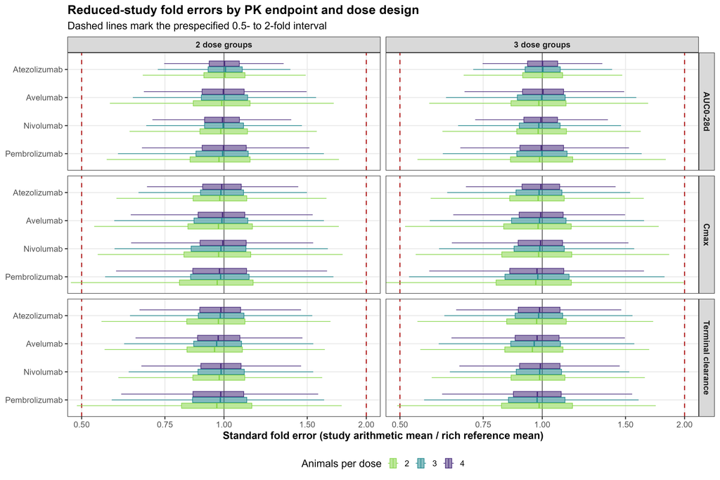

Standard fold-error distributions for AUC0-28d, Cmax, and terminal clearance.

## Power-style operating characteristics

The y-axis is the fraction of simulated studies for which every selected dose group is within 2-fold for the indicated PK endpoint.

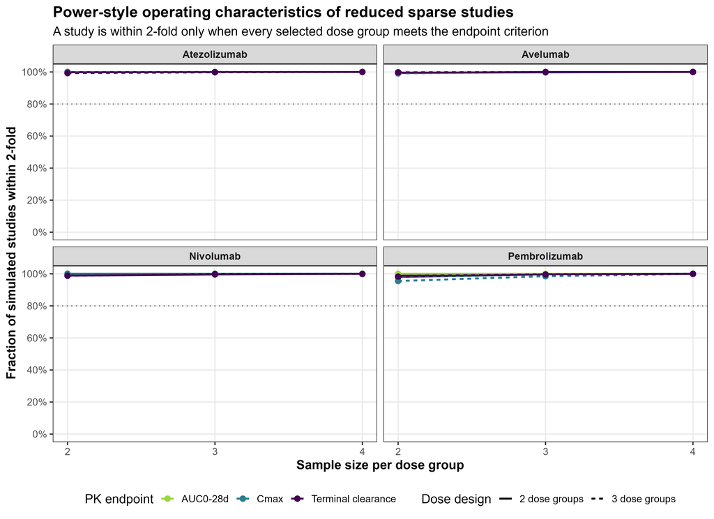

Fraction of simulated studies within 2-fold by sample size per dose group.

## Endpoint success summary

```r
if (!file.exists(endpoint_success_file)) {
  stop(
    "The endpoint success table is missing: ",
    endpoint_success_file,
    ". Run RunReducedSparsePKAnalysis.R first."
  )
}

endpoint_success <- read.csv(
  endpoint_success_file,
  stringsAsFactors = FALSE
)

stopifnot(
  setequal(sort(unique(endpoint_success$N_per_group)), N_PER_GROUP),
  !any(endpoint_success$N_per_group == 5),
  setequal(unique(endpoint_success$Endpoint), ENDPOINTS)
)

endpoint_success |>
  mutate(
    Fraction_within_2fold = round(Fraction_within_2fold, 3)
  ) |>
  arrange(Drug, Endpoint, Design, N_per_group) |>
  kable(
    caption = paste(
      "Fraction of simulated studies within 2-fold for every selected dose",
      "group, by endpoint, design, and group size."
    ),
    col.names = c(
      "Drug",
      "Design",
      "Animals per dose",
      "Total animals",
      "Endpoint",
      "Fraction within 2-fold"
    )
  )
```

Fraction of simulated studies within 2-fold for every selected dose group, by endpoint, design, and group size.

| Drug | Design | Animals per dose | Total animals | Endpoint | Fraction within 2-fold |
| --- | --- | --- | --- | --- | --- |
| Atezolizumab | 2 dose groups | 2 | 4 | AUC0-28d | 1.000 |
| Atezolizumab | 2 dose groups | 3 | 6 | AUC0-28d | 1.000 |
| Atezolizumab | 2 dose groups | 4 | 8 | AUC0-28d | 1.000 |
| Atezolizumab | 3 dose groups | 2 | 6 | AUC0-28d | 1.000 |
| Atezolizumab | 3 dose groups | 3 | 9 | AUC0-28d | 1.000 |
| Atezolizumab | 3 dose groups | 4 | 12 | AUC0-28d | 1.000 |
| Atezolizumab | 2 dose groups | 2 | 4 | Cmax | 1.000 |
| Atezolizumab | 2 dose groups | 3 | 6 | Cmax | 1.000 |
| Atezolizumab | 2 dose groups | 4 | 8 | Cmax | 1.000 |
| Atezolizumab | 3 dose groups | 2 | 6 | Cmax | 1.000 |
| Atezolizumab | 3 dose groups | 3 | 9 | Cmax | 1.000 |
| Atezolizumab | 3 dose groups | 4 | 12 | Cmax | 1.000 |
| Atezolizumab | 2 dose groups | 2 | 4 | Terminal clearance | 0.998 |
| Atezolizumab | 2 dose groups | 3 | 6 | Terminal clearance | 1.000 |
| Atezolizumab | 2 dose groups | 4 | 8 | Terminal clearance | 1.000 |
| Atezolizumab | 3 dose groups | 2 | 6 | Terminal clearance | 0.993 |
| Atezolizumab | 3 dose groups | 3 | 9 | Terminal clearance | 0.998 |
| Atezolizumab | 3 dose groups | 4 | 12 | Terminal clearance | 1.000 |
| Avelumab | 2 dose groups | 2 | 4 | AUC0-28d | 0.994 |
| Avelumab | 2 dose groups | 3 | 6 | AUC0-28d | 1.000 |
| Avelumab | 2 dose groups | 4 | 8 | AUC0-28d | 1.000 |
| Avelumab | 3 dose groups | 2 | 6 | AUC0-28d | 0.993 |
| Avelumab | 3 dose groups | 3 | 9 | AUC0-28d | 1.000 |
| Avelumab | 3 dose groups | 4 | 12 | AUC0-28d | 1.000 |
| Avelumab | 2 dose groups | 2 | 4 | Cmax | 0.996 |
| Avelumab | 2 dose groups | 3 | 6 | Cmax | 0.997 |
| Avelumab | 2 dose groups | 4 | 8 | Cmax | 1.000 |
| Avelumab | 3 dose groups | 2 | 6 | Cmax | 0.991 |
| Avelumab | 3 dose groups | 3 | 9 | Cmax | 0.999 |
| Avelumab | 3 dose groups | 4 | 12 | Cmax | 1.000 |
| Avelumab | 2 dose groups | 2 | 4 | Terminal clearance | 0.994 |
| Avelumab | 2 dose groups | 3 | 6 | Terminal clearance | 1.000 |
| Avelumab | 2 dose groups | 4 | 8 | Terminal clearance | 1.000 |
| Avelumab | 3 dose groups | 2 | 6 | Terminal clearance | 0.998 |
| Avelumab | 3 dose groups | 3 | 9 | Terminal clearance | 1.000 |
| Avelumab | 3 dose groups | 4 | 12 | Terminal clearance | 1.000 |
| Nivolumab | 2 dose groups | 2 | 4 | AUC0-28d | 1.000 |
| Nivolumab | 2 dose groups | 3 | 6 | AUC0-28d | 1.000 |
| Nivolumab | 2 dose groups | 4 | 8 | AUC0-28d | 1.000 |
| Nivolumab | 3 dose groups | 2 | 6 | AUC0-28d | 1.000 |
| Nivolumab | 3 dose groups | 3 | 9 | AUC0-28d | 1.000 |
| Nivolumab | 3 dose groups | 4 | 12 | AUC0-28d | 1.000 |
| Nivolumab | 2 dose groups | 2 | 4 | Cmax | 1.000 |
| Nivolumab | 2 dose groups | 3 | 6 | Cmax | 1.000 |
| Nivolumab | 2 dose groups | 4 | 8 | Cmax | 1.000 |
| Nivolumab | 3 dose groups | 2 | 6 | Cmax | 1.000 |
| Nivolumab | 3 dose groups | 3 | 9 | Cmax | 1.000 |
| Nivolumab | 3 dose groups | 4 | 12 | Cmax | 1.000 |
| Nivolumab | 2 dose groups | 2 | 4 | Terminal clearance | 0.989 |
| Nivolumab | 2 dose groups | 3 | 6 | Terminal clearance | 0.996 |
| Nivolumab | 2 dose groups | 4 | 8 | Terminal clearance | 1.000 |
| Nivolumab | 3 dose groups | 2 | 6 | Terminal clearance | 0.988 |
| Nivolumab | 3 dose groups | 3 | 9 | Terminal clearance | 0.998 |
| Nivolumab | 3 dose groups | 4 | 12 | Terminal clearance | 0.999 |
| Pembrolizumab | 2 dose groups | 2 | 4 | AUC0-28d | 1.000 |
| Pembrolizumab | 2 dose groups | 3 | 6 | AUC0-28d | 1.000 |
| Pembrolizumab | 2 dose groups | 4 | 8 | AUC0-28d | 1.000 |
| Pembrolizumab | 3 dose groups | 2 | 6 | AUC0-28d | 1.000 |
| Pembrolizumab | 3 dose groups | 3 | 9 | AUC0-28d | 1.000 |
| Pembrolizumab | 3 dose groups | 4 | 12 | AUC0-28d | 1.000 |
| Pembrolizumab | 2 dose groups | 2 | 4 | Cmax | 0.979 |
| Pembrolizumab | 2 dose groups | 3 | 6 | Cmax | 0.997 |
| Pembrolizumab | 2 dose groups | 4 | 8 | Cmax | 1.000 |
| Pembrolizumab | 3 dose groups | 2 | 6 | Cmax | 0.955 |
| Pembrolizumab | 3 dose groups | 3 | 9 | Cmax | 0.985 |
| Pembrolizumab | 3 dose groups | 4 | 12 | Cmax | 0.999 |
| Pembrolizumab | 2 dose groups | 2 | 4 | Terminal clearance | 0.988 |
| Pembrolizumab | 2 dose groups | 3 | 6 | Terminal clearance | 0.997 |
| Pembrolizumab | 2 dose groups | 4 | 8 | Terminal clearance | 0.999 |
| Pembrolizumab | 3 dose groups | 2 | 6 | Terminal clearance | 0.983 |
| Pembrolizumab | 3 dose groups | 3 | 9 | Terminal clearance | 0.996 |
| Pembrolizumab | 3 dose groups | 4 | 12 | Terminal clearance | 1.000 |